# Taller 9

Métodos Computacionales para Políticas Públicas - URosario

**Entrega: viernes 1-nov-2019 11:59 PM**

**Juan Camilo Salgado Ramírez**  
juanca.salgado@urosario.edu.co

## Instrucciones:

- Guarde una copia de este *Jupyter Notebook* en su computador, idealmente en una carpeta destinada al material del curso.
- Modifique el nombre del archivo del *notebook*, agregando al final un guión inferior y su nombre y apellido, separados estos últimos por otro guión inferior. Por ejemplo, mi *notebook* se llamaría: mcpp_taller9_santiago_matallana
- Marque el *notebook* con su nombre y e-mail en el bloque verde arriba. Reemplace el texto "[Su nombre acá]" con su nombre y apellido. Similar para su e-mail.
- Desarrolle la totalidad del taller sobre este *notebook*, insertando las celdas que sea necesario debajo de cada pregunta. Haga buen uso de las celdas para código y de las celdas tipo *markdown* según el caso.
- Recuerde salvar periódicamente sus avances.
- Cuando termine el taller:
  1. Descárguelo en PDF. Si tiene algún problema con la conversión, descárguelo en HTML.
  2. Suba todos los archivos a su repositorio en GitHub, en una carpeta destinada exclusivamente para este taller, antes de la fecha y hora límites.

NLTK Book (http://www.nltk.org/book/), Exercises:

- Chapter 1: 22, 26, 28
- Chapter 2: 2, 4, 11

### Capitulo 1

#### Ejercicio 22

Find all the four-letter words in the Chat Corpus (text5). With the help of a frequency distribution (FreqDist), show these words in decreasing order of frequency.

```python
import nltk
"""
nltk.download()
"""
```

```
'\nnltk.download()\n'
```

```python
from nltk.book import *
from nltk.probability import FreqDist
import matplotlib.pyplot as plt
```

```
*** Introductory Examples for the NLTK Book ***
Loading text1, ..., text9 and sent1, ..., sent9
Type the name of the text or sentence to view it.
Type: 'texts()' or 'sents()' to list the materials.
text1: Moby Dick by Herman Melville 1851
text2: Sense and Sensibility by Jane Austen 1811
text3: The Book of Genesis
text4: Inaugural Address Corpus
text5: Chat Corpus
text6: Monty Python and the Holy Grail
text7: Wall Street Journal
text8: Personals Corpus
text9: The Man Who Was Thursday by G . K . Chesterton 1908
```

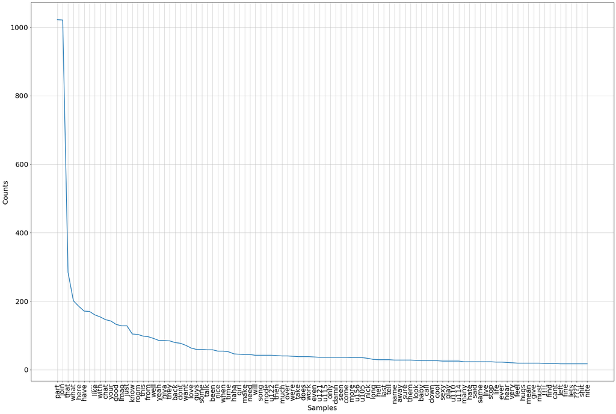

```python
cuatro_pal = [x for x in text5 if len(x) == 4]
fdist = FreqDist(word.lower() for word in cuatro_pal)
len(fdist)
# Mostrar 100 palabras con mas ocurrencias
plt.figure(figsize=(30, 20))
plt.rcParams.update({'font.size': 20})
fdist.plot(100)
```

#### Ejercicio 26

What does the following Python code do? sum(len(w) for w in text1) Can you use it to work out the average word length of a text?

```python
# El codigo lo que hace es, basicamente, contar el numero de caracteres que existen en 'text1'.
# La 'list-comprehension' de adentro del parentesis, 'len(w) for w in text1', determina el
# numero de caracteres de cada palabra en 'text1'. Al sacar la funcion 'sum' se estarian
# sumando todos los caracteres. Para determinar el largo promedio de cada palabra en un texto
# basta con dividir esa expresion por 'len(text1)'
```

#### Ejercicio 28

Define a function percent(word, text) that calculates how often a given word occurs in a text, and expresses the result as a percentage.

```python
def percent(word, text):
    return text.count(word)/len(text)

percent('home', text1)
```

```
0.0002147082842891047
```